# Woodstoich Si 2019

## *NOTE: I ran out of time to make the axes all pretty, but NTL_RESULT means total dissolved N concentration, PTL_RESULT means total dissolved P, etc and MICX_RESULT means concentration of microcystin somewhere in the lake. Also all of these stats were rushed through with no regard to statistical assumptions so should be taken with a grain of salt and just represent some quick exploratory stuff*

# PART 1 - Si stoichiometry and microcystin

## Distributions for silica, microcystin - both vary over several orders of magnitude, ~300 zeros removed for microcystin

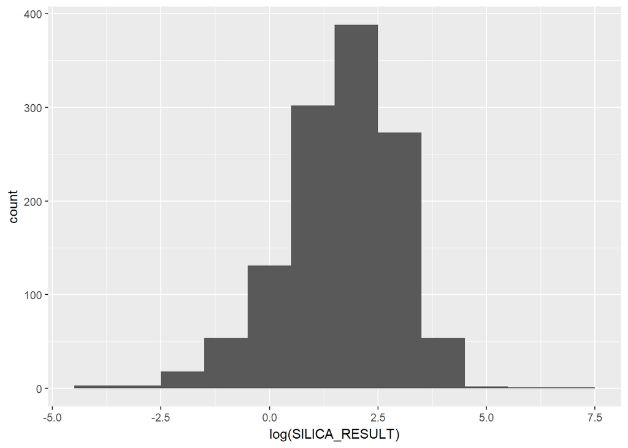

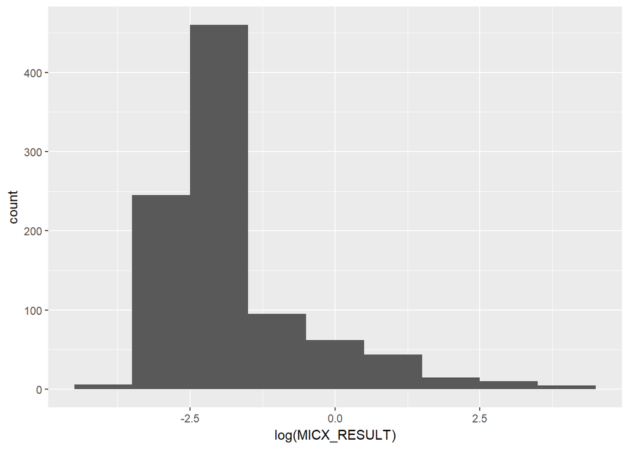

## Si:P vs microcystin

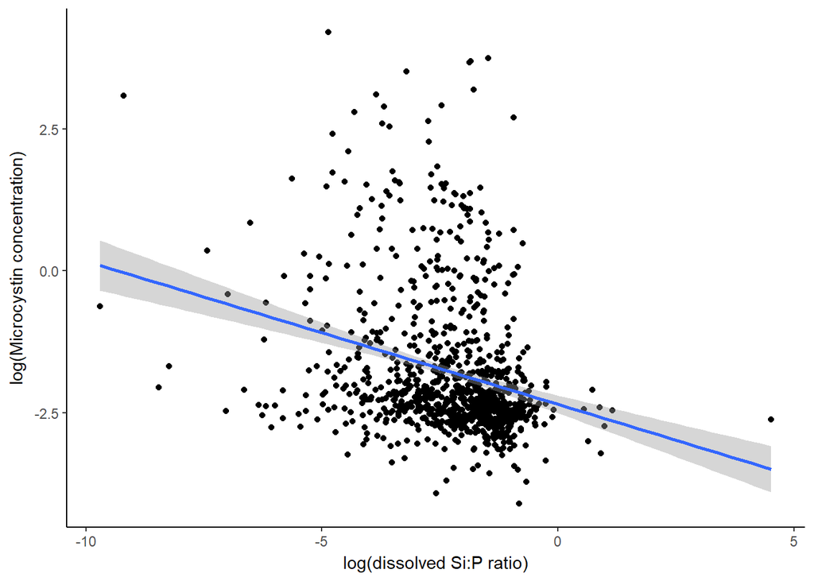

```r
x<-ggplot(data=nla2012_waterchem_wide_nozeros, mapping=aes(x=log(SILICA_RESULT/PTL_RESULT), y=log(MICX_RESULT)))
x+geom_point()+geom_smooth(method="lm")+xlab("log(dissolved Si:P ratio)")+ylab("log(Microcystin concentration)")+theme_classic()
```

```r
fit<-lm(data=nla2012_waterchem_wide_nozeros, log(MICX_RESULT)~log((SILICA_RESULT/PTL_RESULT)))
summary(fit)
```

```
##
## Call:
## lm(formula = log(MICX_RESULT) ~ log((SILICA_RESULT/PTL_RESULT)),
##     data = nla2012_waterchem_wide_nozeros)
##
## Residuals:
##     Min      1Q  Median      3Q     Max
## -2.2141 -0.7249 -0.3703  0.2447  5.7198
##
## Coefficients:
##                                 Estimate Std. Error t value Pr(>|t|)
## (Intercept)                     -2.35159    0.07957 -29.554   <2e-16 ***
## log((SILICA_RESULT/PTL_RESULT)) -0.25222    0.02990  -8.436   <2e-16 ***
## ---
## Signif. codes:  0 '***' 0.001 '**' 0.01 '*' 0.05 '.' 0.1 ' ' 1
##
## Residual standard error: 1.221 on 940 degrees of freedom
## Multiple R-squared:  0.07037,    Adjusted R-squared:  0.06939
## F-statistic: 71.16 on 1 and 940 DF,  p-value: < 2.2e-16
```

## Si:N vs. microcystin

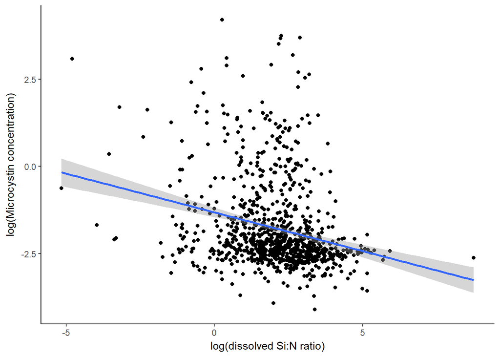

```r
x<-ggplot(data=nla2012_waterchem_wide_nozeros, mapping=aes(x=log(SILICA_RESULT/NTL_RESULT), y=log(MICX_RESULT)))
x+geom_point()+geom_smooth(method="lm")+xlab("log(dissolved Si:N ratio)")+ylab("log(Microcystin concentration)")+theme_classic()
```

```r
fit<-lm(data=nla2012_waterchem_wide_nozeros, log(MICX_RESULT)~log((SILICA_RESULT/NTL_RESULT)))
summary(fit)
```

```
##
## Call:
## lm(formula = log(MICX_RESULT) ~ log((SILICA_RESULT/NTL_RESULT)),
##     data = nla2012_waterchem_wide_nozeros)
##
## Residuals:
##     Min      1Q  Median      3Q     Max
## -2.1820 -0.7342 -0.3487  0.2287  5.6434
##
## Coefficients:
##                                 Estimate Std. Error t value Pr(>|t|)
## (Intercept)                     -1.31669    0.06872 -19.161  < 2e-16 ***
## log((SILICA_RESULT/NTL_RESULT)) -0.22194    0.02737  -8.108  1.6e-15 ***
## ---
## Signif. codes:  0 '***' 0.001 '**' 0.01 '*' 0.05 '.' 0.1 ' ' 1
##
## Residual standard error: 1.225 on 940 degrees of freedom
## Multiple R-squared:  0.06536,    Adjusted R-squared:  0.06436
## F-statistic: 65.73 on 1 and 940 DF,  p-value: 1.601e-15
```

## Si:N and Si:P both explain microcystin in complementary ways accoriding to partial regression plots. Also both Si:N and Si:P are retained in the model

```r
fit<-lm(data=nla2012_waterchem_wide_nozeros, log(MICX_RESULT)~log(SILICA_RESULT/NTL_RESULT)+log((SILICA_RESULT/PTL_RESULT)))
summary(fit)
```

```
##
## Call:
## lm(formula = log(MICX_RESULT) ~ log(SILICA_RESULT/NTL_RESULT) +
##     log((SILICA_RESULT/PTL_RESULT)), data = nla2012_waterchem_wide_nozeros)
##
## Residuals:
##     Min      1Q  Median      3Q     Max
## -2.1955 -0.7296 -0.3591  0.2201  5.6662
##
## Coefficients:
##                                 Estimate Std. Error t value Pr(>|t|)
## (Intercept)                     -1.94226    0.21762  -8.925  < 2e-16 ***
## log(SILICA_RESULT/NTL_RESULT)   -0.09887    0.04894  -2.020  0.04363 *
## log((SILICA_RESULT/PTL_RESULT)) -0.16229    0.05359  -3.028  0.00253 **
## ---
## Signif. codes:  0 '***' 0.001 '**' 0.01 '*' 0.05 '.' 0.1 ' ' 1
##
## Residual standard error: 1.219 on 939 degrees of freedom
## Multiple R-squared:  0.0744, Adjusted R-squared:  0.07243
## F-statistic: 37.74 on 2 and 939 DF,  p-value: < 2.2e-16
```

```r
stepAIC(fit)
```

```
## Start:  AIC=376.44
## log(MICX_RESULT) ~ log(SILICA_RESULT/NTL_RESULT) + log((SILICA_RESULT/PTL_RESULT))
##
##                                   Df Sum of Sq    RSS    AIC
## <none>                                         1395.8 376.44
## - log(SILICA_RESULT/NTL_RESULT)    1    6.0675 1401.9 378.52
## - log((SILICA_RESULT/PTL_RESULT))  1   13.6312 1409.5 383.59
```

```
##
## Call:
## lm(formula = log(MICX_RESULT) ~ log(SILICA_RESULT/NTL_RESULT) +
##     log((SILICA_RESULT/PTL_RESULT)), data = nla2012_waterchem_wide_nozeros)
##
## Coefficients:
##                     (Intercept)    log(SILICA_RESULT/NTL_RESULT)
##                        -1.94226                         -0.09887
## log((SILICA_RESULT/PTL_RESULT))
##                        -0.16229
```

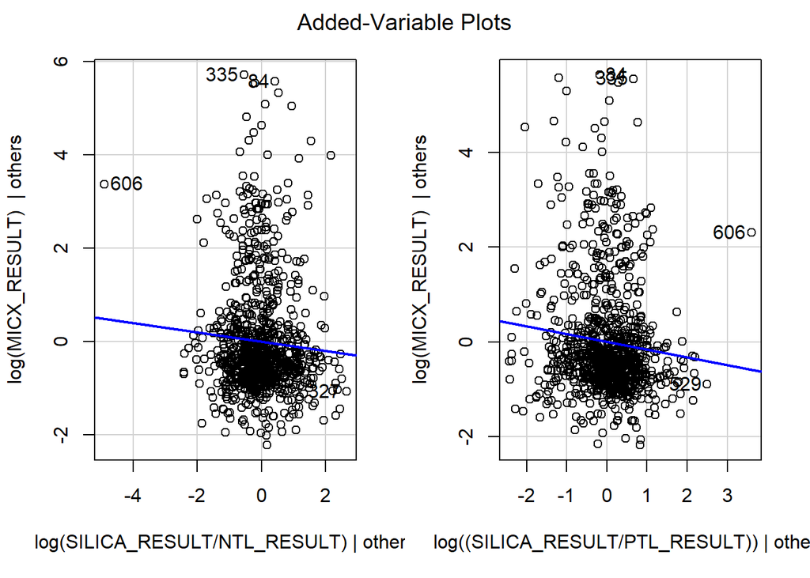

```r
avPlots(fit)
```

## Same as above but just Si N P concentrations instead of ratios. This suggests that only N concentrations have an effect

```r
fit<-lm(data=nla2012_waterchem_wide_nozeros, log(MICX_RESULT)~log(SILICA_RESULT)+log(PTL_RESULT)+log(NTL_RESULT))
summary(fit)
```

```
##
## Call:
## lm(formula = log(MICX_RESULT) ~ log(SILICA_RESULT) + log(PTL_RESULT) +
##     log(NTL_RESULT), data = nla2012_waterchem_wide_nozeros)
##
## Residuals:
##     Min      1Q  Median      3Q     Max
## -3.0630 -0.6486 -0.1965  0.3530  5.3614
##
## Coefficients:
##                    Estimate Std. Error t value Pr(>|t|)
## (Intercept)        -1.70029    0.19815  -8.581   <2e-16 ***
## log(SILICA_RESULT) -0.02187    0.03212  -0.681    0.496
## log(PTL_RESULT)     0.03815    0.04939   0.772    0.440
## log(NTL_RESULT)     0.59145    0.05627  10.511   <2e-16 ***
## ---
## Signif. codes:  0 '***' 0.001 '**' 0.01 '*' 0.05 '.' 0.1 ' ' 1
##
## Residual standard error: 1.106 on 938 degrees of freedom
## Multiple R-squared:  0.239,  Adjusted R-squared:  0.2366
## F-statistic: 98.21 on 3 and 938 DF,  p-value: < 2.2e-16
```

```r
stepAIC(fit)
```

```
## Start:  AIC=193.94
## log(MICX_RESULT) ~ log(SILICA_RESULT) + log(PTL_RESULT) + log(NTL_RESULT)
##
##                      Df Sum of Sq    RSS    AIC
## - log(SILICA_RESULT)  1     0.567 1148.1 192.41
## - log(PTL_RESULT)     1     0.730 1148.3 192.54
## <none>                            1147.6 193.94
## - log(NTL_RESULT)     1   135.156 1282.7 296.82
##
## Step:  AIC=192.41
## log(MICX_RESULT) ~ log(PTL_RESULT) + log(NTL_RESULT)
##
##                   Df Sum of Sq    RSS    AIC
## - log(PTL_RESULT)  1     0.332 1148.5 190.68
## <none>                         1148.1 192.41
## - log(NTL_RESULT)  1   146.348 1294.5 303.42
##
## Step:  AIC=190.68
## log(MICX_RESULT) ~ log(NTL_RESULT)
##
##                   Df Sum of Sq    RSS    AIC
## <none>                         1148.5 190.68
## - log(NTL_RESULT)  1    359.57 1508.0 445.26
```

```
##
## Call:
## lm(formula = log(MICX_RESULT) ~ log(NTL_RESULT), data = nla2012_waterchem_wide_nozeros)
##
## Coefficients:
##     (Intercept)  log(NTL_RESULT)
##         -1.5748           0.6214
```

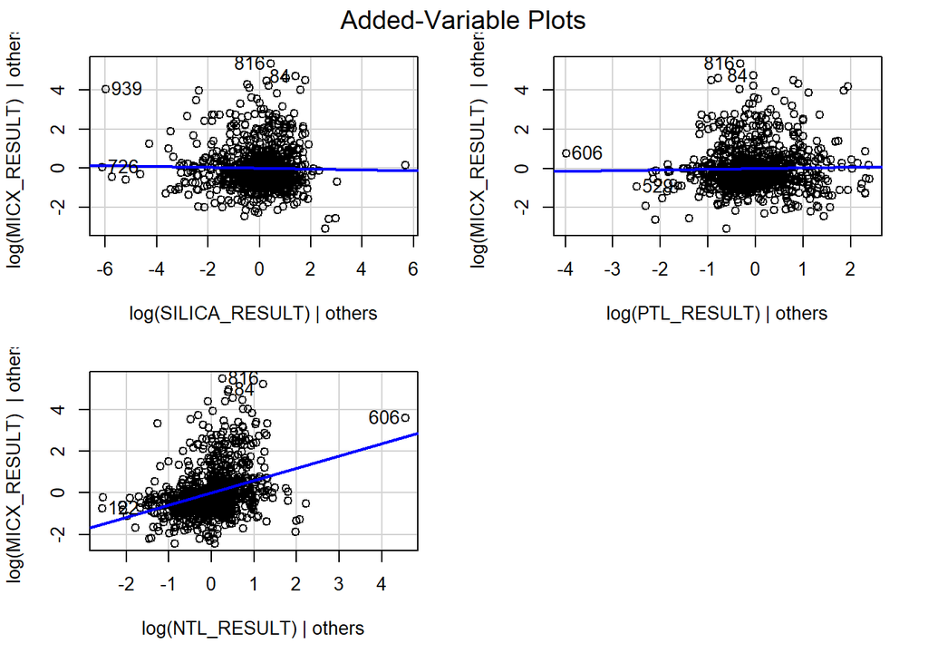

```r
avPlots(fit)
```

## N:P ratio doesn’t explain much

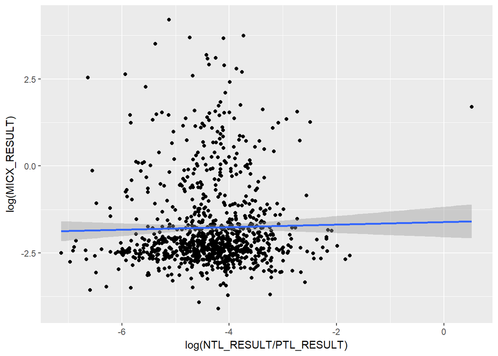

```r
x<-ggplot(data=nla2012_waterchem_wide_nozeros, mapping=aes(x=log(NTL_RESULT/PTL_RESULT), y=log(MICX_RESULT)))
x+geom_point()+geom_smooth(method="lm")
```

```r
#fit<-lm(data=nla2012_waterchem_wide, log(MICX_RESULT)~log((NTL_RESULT/PTL_RESULT)))
#summary(fit)
```

## trying to throw Si:N, Si:P, and N:P in one model totally fails, probably for obvious reasons that I haven’t figured out yet

```r
fit<-lm(data=nla2012_waterchem_wide_nozeros, log(MICX_RESULT)~log(NTL_RESULT/PTL_RESULT)+log(SILICA_RESULT/PTL_RESULT)+log(SILICA_RESULT/NTL_RESULT))
summary(fit)
```

```
##
## Call:
## lm(formula = log(MICX_RESULT) ~ log(NTL_RESULT/PTL_RESULT) +
##     log(SILICA_RESULT/PTL_RESULT) + log(SILICA_RESULT/NTL_RESULT),
##     data = nla2012_waterchem_wide_nozeros)
##
## Residuals:
##     Min      1Q  Median      3Q     Max
## -2.1955 -0.7296 -0.3591  0.2201  5.6662
##
## Coefficients: (1 not defined because of singularities)
##                               Estimate Std. Error t value Pr(>|t|)
## (Intercept)                   -1.94226    0.21762  -8.925   <2e-16 ***
## log(NTL_RESULT/PTL_RESULT)     0.09887    0.04894   2.020   0.0436 *
## log(SILICA_RESULT/PTL_RESULT) -0.26116    0.03018  -8.654   <2e-16 ***
## log(SILICA_RESULT/NTL_RESULT)       NA         NA      NA       NA
## ---
## Signif. codes:  0 '***' 0.001 '**' 0.01 '*' 0.05 '.' 0.1 ' ' 1
##
## Residual standard error: 1.219 on 939 degrees of freedom
## Multiple R-squared:  0.0744, Adjusted R-squared:  0.07243
## F-statistic: 37.74 on 2 and 939 DF,  p-value: < 2.2e-16
```

```r
stepAIC(fit)
```

```
## Start:  AIC=376.44
## log(MICX_RESULT) ~ log(NTL_RESULT/PTL_RESULT) + log(SILICA_RESULT/PTL_RESULT) +
##     log(SILICA_RESULT/NTL_RESULT)
##
##
## Step:  AIC=376.44
## log(MICX_RESULT) ~ log(NTL_RESULT/PTL_RESULT) + log(SILICA_RESULT/PTL_RESULT)
##
##                                 Df Sum of Sq    RSS    AIC
## <none>                                       1395.8 376.44
## - log(NTL_RESULT/PTL_RESULT)     1     6.068 1401.9 378.52
## - log(SILICA_RESULT/PTL_RESULT)  1   111.336 1507.2 446.73
```

```
##
## Call:
## lm(formula = log(MICX_RESULT) ~ log(NTL_RESULT/PTL_RESULT) +
##     log(SILICA_RESULT/PTL_RESULT), data = nla2012_waterchem_wide_nozeros)
##
## Coefficients:
##                   (Intercept)     log(NTL_RESULT/PTL_RESULT)
##                      -1.94226                        0.09887
## log(SILICA_RESULT/PTL_RESULT)
##                      -0.26116
```

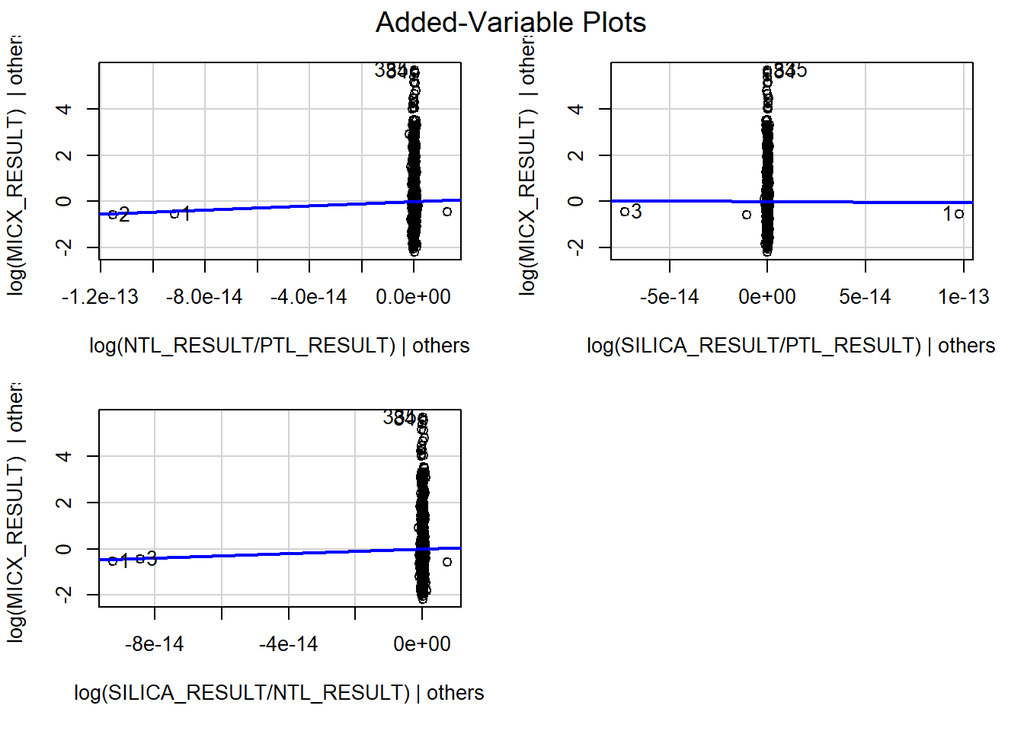

```r
avPlots(fit)
```

# PART 2 - Si:N, Si:P, N:P and community composition

```r
nla2012_wide_phytoplankton_count_02122014 <- read_csv("C:/Users/pkthomas88/Box Sync/1. Woodstoich/nla2012_wide_phytoplankton_count_02122014.csv")
nla2012_chem_phyto_joined<-full_join(nla2012_wide_phytoplankton_count_02122014, nla2012_waterchem_wide_nozeros, by="UID")


cyanos<-subset(nla2012_chem_phyto_joined, ALGAL_GROUP=="BLUE-GREEN ALGAE")
diatoms<-subset(nla2012_chem_phyto_joined, ALGAL_GROUP=="DIATOM")
```

## Si stoich vs cyanobacteria total biovolume

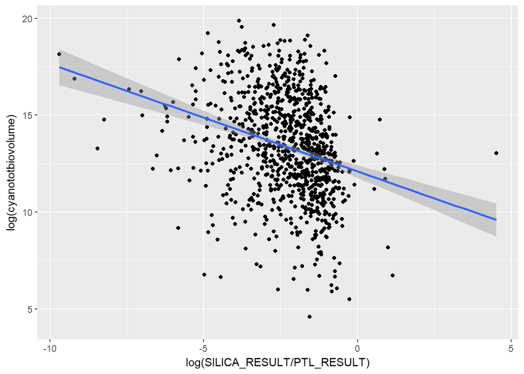

```r
group_by(cyanos, UID) %>% summarize(cyanototbiovolume=sum(BIOVOLUME)) -> poop
nla2012_cyanos<-full_join(nla2012_waterchem_wide_nozeros,poop, by="UID")

ggplot(data=nla2012_cyanos, mapping = aes(x=log(SILICA_RESULT/PTL_RESULT), y=log(cyanototbiovolume)))+
  geom_point()+geom_smooth(method = "lm")
```

```r
fit<-lm(data=nla2012_cyanos, log(cyanototbiovolume)~log(SILICA_RESULT/PTL_RESULT))
summary(fit)
```

```
##
## Call:
## lm(formula = log(cyanototbiovolume) ~ log(SILICA_RESULT/PTL_RESULT),
##     data = nla2012_cyanos)
##
## Residuals:
##     Min      1Q  Median      3Q     Max
## -8.3738 -1.6783  0.0496  1.7988  6.1198
##
## Coefficients:
##                               Estimate Std. Error t value Pr(>|t|)
## (Intercept)                   12.09764    0.16692  72.476   <2e-16 ***
## log(SILICA_RESULT/PTL_RESULT) -0.55446    0.06269  -8.844   <2e-16 ***
## ---
## Signif. codes:  0 '***' 0.001 '**' 0.01 '*' 0.05 '.' 0.1 ' ' 1
##
## Residual standard error: 2.544 on 926 degrees of freedom
##   (303 observations deleted due to missingness)
## Multiple R-squared:  0.07789,    Adjusted R-squared:  0.0769
## F-statistic: 78.22 on 1 and 926 DF,  p-value: < 2.2e-16
```

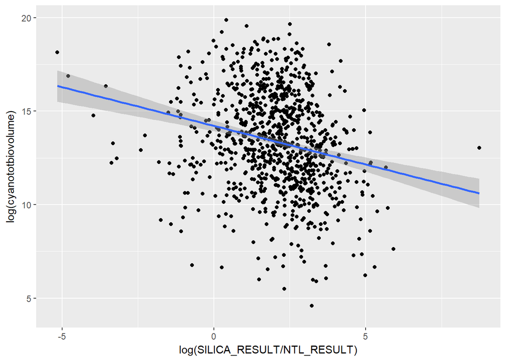

```r
ggplot(data=nla2012_cyanos, mapping = aes(x=log(SILICA_RESULT/NTL_RESULT), y=log(cyanototbiovolume)))+
  geom_point()+geom_smooth(method = "lm")
```

```r
fit<-lm(data=nla2012_cyanos, log(cyanototbiovolume)~log(SILICA_RESULT/NTL_RESULT))
summary(fit)
```

```
##
## Call:
## lm(formula = log(cyanototbiovolume) ~ log(SILICA_RESULT/NTL_RESULT),
##     data = nla2012_cyanos)
##
## Residuals:
##     Min      1Q  Median      3Q     Max
## -8.3013 -1.7328 -0.0134  1.8206  6.4655
##
## Coefficients:
##                               Estimate Std. Error t value Pr(>|t|)
## (Intercept)                   14.21650    0.14567  97.594  < 2e-16 ***
## log(SILICA_RESULT/NTL_RESULT) -0.41308    0.05823  -7.093  2.6e-12 ***
## ---
## Signif. codes:  0 '***' 0.001 '**' 0.01 '*' 0.05 '.' 0.1 ' ' 1
##
## Residual standard error: 2.58 on 926 degrees of freedom
##   (303 observations deleted due to missingness)
## Multiple R-squared:  0.05154,    Adjusted R-squared:  0.05051
## F-statistic: 50.32 on 1 and 926 DF,  p-value: 2.598e-12
```

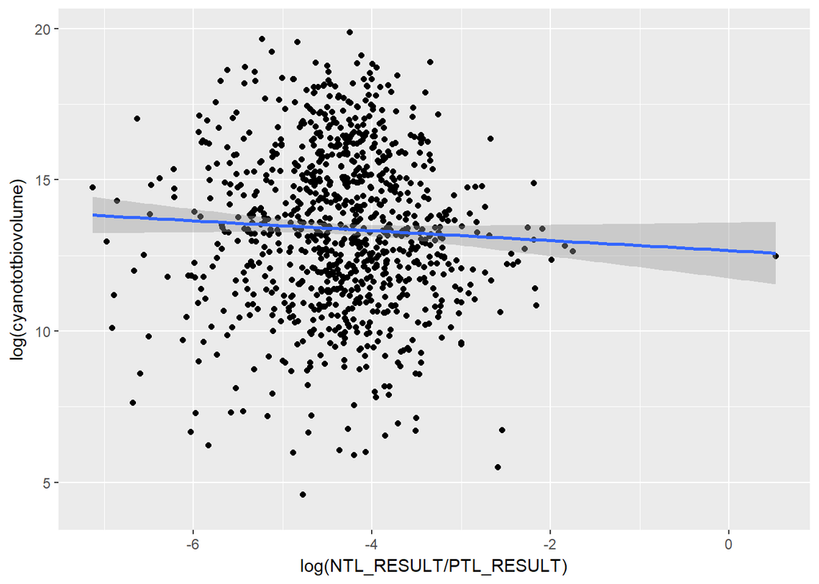

```r
ggplot(data=nla2012_cyanos, mapping = aes(x=log(NTL_RESULT/PTL_RESULT), y=log(cyanototbiovolume)))+
  geom_point()+geom_smooth(method = "lm")
```

```r
fit<-lm(data=nla2012_cyanos, log(cyanototbiovolume)~log(NTL_RESULT/PTL_RESULT))
summary(fit)
```

```
##
## Call:
## lm(formula = log(cyanototbiovolume) ~ log(NTL_RESULT/PTL_RESULT),
##     data = nla2012_cyanos)
##
## Residuals:
##     Min      1Q  Median      3Q     Max
## -8.8643 -1.7907 -0.0452  1.8434  6.5080
##
## Coefficients:
##                            Estimate Std. Error t value Pr(>|t|)
## (Intercept)                 12.6651     0.4679  27.068   <2e-16 ***
## log(NTL_RESULT/PTL_RESULT)  -0.1637     0.1059  -1.546    0.122
## ---
## Signif. codes:  0 '***' 0.001 '**' 0.01 '*' 0.05 '.' 0.1 ' ' 1
##
## Residual standard error: 2.646 on 926 degrees of freedom
##   (303 observations deleted due to missingness)
## Multiple R-squared:  0.002574,   Adjusted R-squared:  0.001497
## F-statistic:  2.39 on 1 and 926 DF,  p-value: 0.1225
```

## Unlike the above microcystin data, only Si:P has an effect on cyanobacteria biovolume when it’s put in a model with Si:N. hmm.

```r
fit<-lm(data=nla2012_cyanos, log(cyanototbiovolume)~ log(SILICA_RESULT/PTL_RESULT)+ log(SILICA_RESULT/NTL_RESULT))
summary(fit)
```

```
##
## Call:
## lm(formula = log(cyanototbiovolume) ~ log(SILICA_RESULT/PTL_RESULT) +
##     log(SILICA_RESULT/NTL_RESULT), data = nla2012_cyanos)
##
## Residuals:
##    Min     1Q Median     3Q    Max
## -8.388 -1.673  0.049  1.793  6.124
##
## Coefficients:
##                               Estimate Std. Error t value Pr(>|t|)
## (Intercept)                   11.98342    0.45688  26.229  < 2e-16 ***
## log(SILICA_RESULT/PTL_RESULT) -0.57956    0.11256  -5.149  3.2e-07 ***
## log(SILICA_RESULT/NTL_RESULT)  0.02769    0.10309   0.269    0.788
## ---
## Signif. codes:  0 '***' 0.001 '**' 0.01 '*' 0.05 '.' 0.1 ' ' 1
##
## Residual standard error: 2.545 on 925 degrees of freedom
##   (303 observations deleted due to missingness)
## Multiple R-squared:  0.07796,    Adjusted R-squared:  0.07597
## F-statistic: 39.11 on 2 and 925 DF,  p-value: < 2.2e-16
```

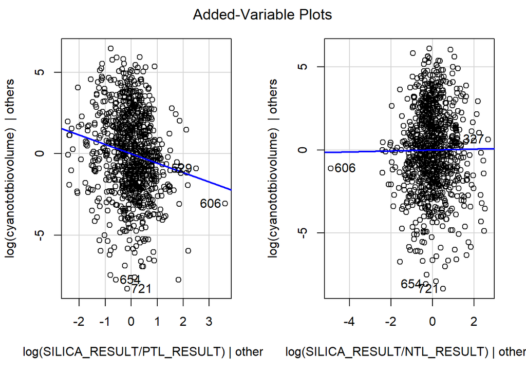

```r
avPlots(fit)
```

## Si stoich vs diatom total biovolume

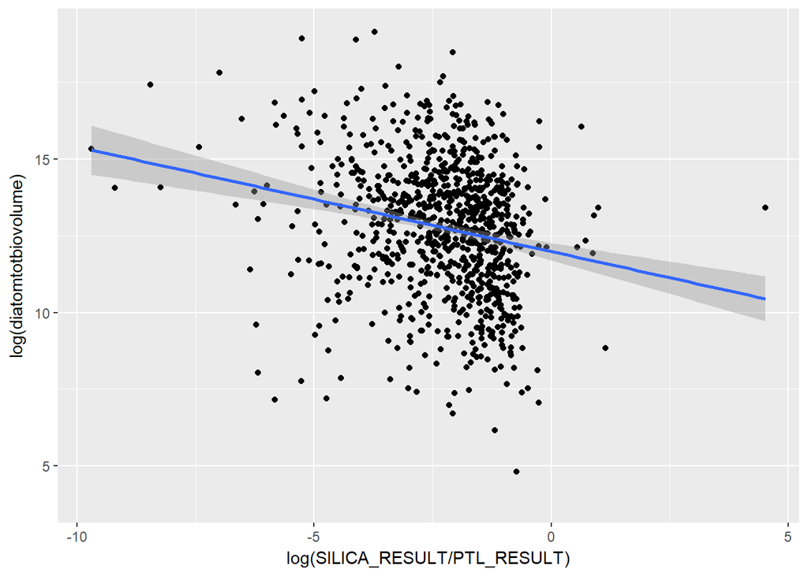

```r
group_by(diatoms, UID) %>% summarize(diatomtotbiovolume=sum(BIOVOLUME)) -> poop
nla2012_diatoms<-full_join(nla2012_cyanos,poop, by="UID")

ggplot(data=nla2012_diatoms, mapping = aes(x=log(SILICA_RESULT/PTL_RESULT), y=log(diatomtotbiovolume)))+
  geom_point()+geom_smooth(method = "lm")
```

```r
fit<-lm(data=nla2012_diatoms, log(diatomtotbiovolume)~log(SILICA_RESULT/PTL_RESULT))
summary(fit)
```

```
##
## Call:
## lm(formula = log(diatomtotbiovolume) ~ log(SILICA_RESULT/PTL_RESULT),
##     data = nla2012_diatoms)
##
## Residuals:
##     Min      1Q  Median      3Q     Max
## -7.4322 -1.4163  0.1754  1.4632  5.8789
##
## Coefficients:
##                               Estimate Std. Error t value Pr(>|t|)
## (Intercept)                   11.98695    0.14304  83.802  < 2e-16 ***
## log(SILICA_RESULT/PTL_RESULT) -0.34073    0.05412  -6.296 4.81e-10 ***
## ---
## Signif. codes:  0 '***' 0.001 '**' 0.01 '*' 0.05 '.' 0.1 ' ' 1
##
## Residual standard error: 2.151 on 879 degrees of freedom
##   (354 observations deleted due to missingness)
## Multiple R-squared:  0.04316,    Adjusted R-squared:  0.04207
## F-statistic: 39.64 on 1 and 879 DF,  p-value: 4.806e-10
```

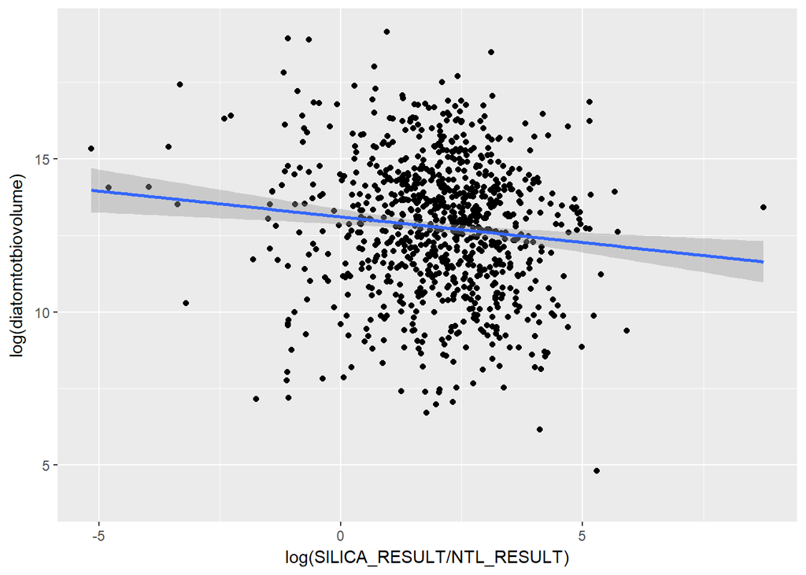

```r
ggplot(data=nla2012_diatoms, mapping = aes(x=log(SILICA_RESULT/NTL_RESULT), y=log(diatomtotbiovolume)))+
  geom_point()+geom_smooth(method = "lm")
```

```r
fit<-lm(data=nla2012_diatoms, log(diatomtotbiovolume)~log(SILICA_RESULT/NTL_RESULT))
summary(fit)
```

```
##
## Call:
## lm(formula = log(diatomtotbiovolume) ~ log(SILICA_RESULT/NTL_RESULT),
##     data = nla2012_diatoms)
##
## Residuals:
##     Min      1Q  Median      3Q     Max
## -7.4129 -1.4129  0.1852  1.4368  6.1891
##
## Coefficients:
##                               Estimate Std. Error t value Pr(>|t|)
## (Intercept)                   13.10679    0.12570 104.269  < 2e-16 ***
## log(SILICA_RESULT/NTL_RESULT) -0.16790    0.04983  -3.369 0.000786 ***
## ---
## Signif. codes:  0 '***' 0.001 '**' 0.01 '*' 0.05 '.' 0.1 ' ' 1
##
## Residual standard error: 2.185 on 879 degrees of freedom
##   (354 observations deleted due to missingness)
## Multiple R-squared:  0.01275,    Adjusted R-squared:  0.01163
## F-statistic: 11.35 on 1 and 879 DF,  p-value: 0.0007859
```

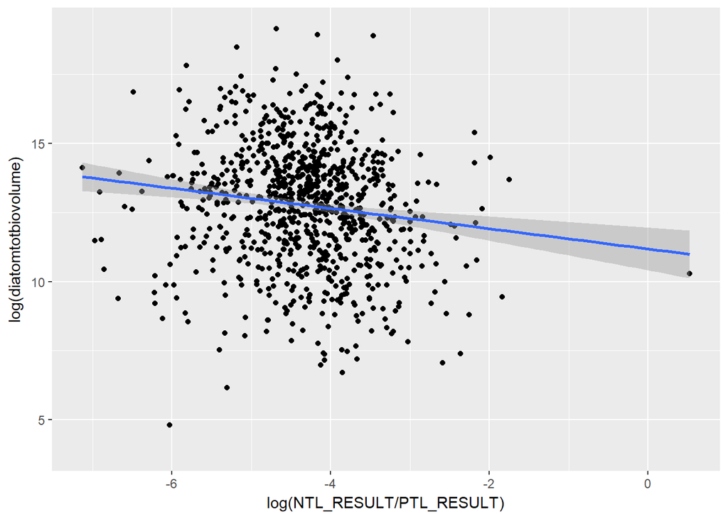

```r
ggplot(data=nla2012_diatoms, mapping = aes(x=log(NTL_RESULT/PTL_RESULT), y=log(diatomtotbiovolume)))+
  geom_point()+geom_smooth(method = "lm")
```

```r
fit<-lm(data=nla2012_diatoms, log(diatomtotbiovolume)~log(NTL_RESULT/PTL_RESULT))
summary(fit)
```

```
##
## Call:
## lm(formula = log(diatomtotbiovolume) ~ log(NTL_RESULT/PTL_RESULT),
##     data = nla2012_diatoms)
##
## Residuals:
##     Min      1Q  Median      3Q     Max
## -8.5820 -1.3857  0.1296  1.4304  6.4246
##
## Coefficients:
##                            Estimate Std. Error t value Pr(>|t|)
## (Intercept)                11.18187    0.39491  28.315   <2e-16 ***
## log(NTL_RESULT/PTL_RESULT) -0.36579    0.08974  -4.076    5e-05 ***
## ---
## Signif. codes:  0 '***' 0.001 '**' 0.01 '*' 0.05 '.' 0.1 ' ' 1
##
## Residual standard error: 2.178 on 879 degrees of freedom
##   (354 observations deleted due to missingness)
## Multiple R-squared:  0.01855,    Adjusted R-squared:  0.01743
## F-statistic: 16.61 on 1 and 879 DF,  p-value: 4.998e-05
```

```r
#mutate(nla2012_diatoms, dia.cyano=diatomtotbiovolume/cyanototbiovolume)
```

## Effects of Si:P etc on ratio of diatoms:cyanobacteria. Not sure what to make of this, but I guess high Si:N and high Si:P both explain the community ratio, however when you put them both in a model only Si:N has an effect. Also total Si concentration has a weaker effect than the ratios

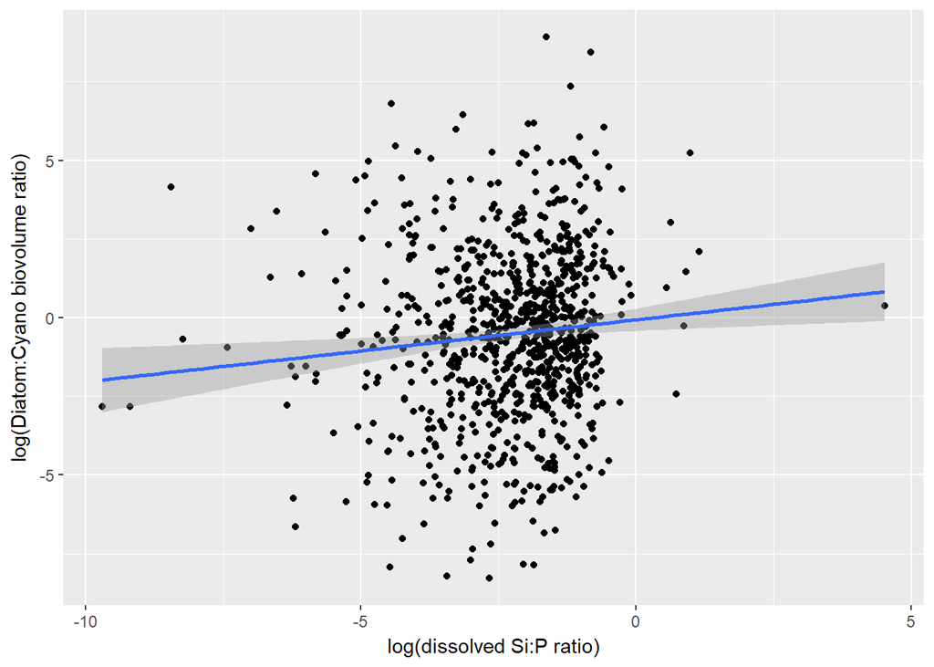

```r
ggplot(data=nla2012_diatoms, mapping = aes(x=log(SILICA_RESULT/PTL_RESULT), y=log(diatomtotbiovolume/cyanototbiovolume)))+
  geom_point()+geom_smooth(method = "lm")+
  xlab("log(dissolved Si:P ratio)")+
  ylab("log(Diatom:Cyano biovolume ratio)")
```

```r
fit<-lm(data=nla2012_diatoms, log(diatomtotbiovolume/cyanototbiovolume)~log(SILICA_RESULT/PTL_RESULT))
summary(fit)
```

```
##
## Call:
## lm(formula = log(diatomtotbiovolume/cyanototbiovolume) ~ log(SILICA_RESULT/PTL_RESULT),
##     data = nla2012_diatoms)
##
## Residuals:
##     Min      1Q  Median      3Q     Max
## -7.6922 -1.7563  0.0701  1.7480  9.3079
##
## Coefficients:
##                               Estimate Std. Error t value Pr(>|t|)
## (Intercept)                   -0.06565    0.18173  -0.361  0.71801
## log(SILICA_RESULT/PTL_RESULT)  0.19739    0.06866   2.875  0.00414 **
## ---
## Signif. codes:  0 '***' 0.001 '**' 0.01 '*' 0.05 '.' 0.1 ' ' 1
##
## Residual standard error: 2.714 on 867 degrees of freedom
##   (366 observations deleted due to missingness)
## Multiple R-squared:  0.009443,   Adjusted R-squared:  0.008301
## F-statistic: 8.265 on 1 and 867 DF,  p-value: 0.00414
```

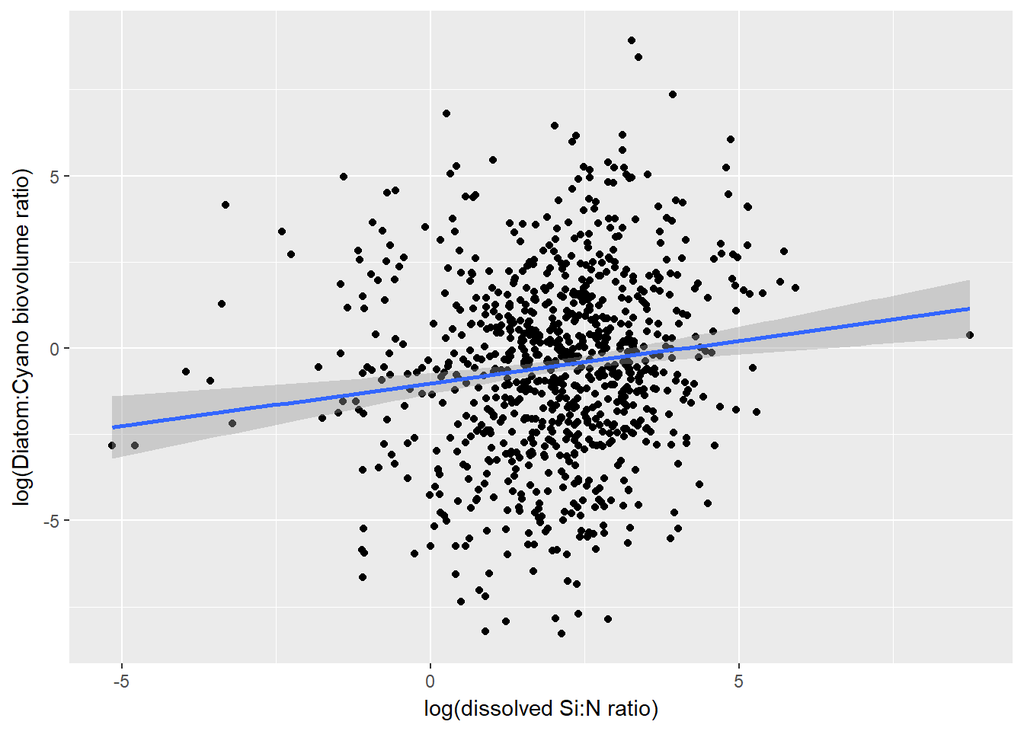

```r
ggplot(data=nla2012_diatoms, mapping = aes(x=log(SILICA_RESULT/NTL_RESULT), y=log(diatomtotbiovolume/cyanototbiovolume)))+
  geom_point()+geom_smooth(method = "lm")+
  xlab("log(dissolved Si:N ratio)")+
  ylab("log(Diatom:Cyano biovolume ratio)")
```

```r
fit<-lm(data=nla2012_diatoms, log(diatomtotbiovolume/cyanototbiovolume)~log(SILICA_RESULT/PTL_RESULT)+log(SILICA_RESULT/NTL_RESULT))
summary(fit)
```

```
##
## Call:
## lm(formula = log(diatomtotbiovolume/cyanototbiovolume) ~ log(SILICA_RESULT/PTL_RESULT) +
##     log(SILICA_RESULT/NTL_RESULT), data = nla2012_diatoms)
##
## Residuals:
##     Min      1Q  Median      3Q     Max
## -7.8348 -1.7391  0.1261  1.7527  9.1084
##
## Coefficients:
##                               Estimate Std. Error t value Pr(>|t|)
## (Intercept)                   -1.39797    0.50108  -2.790  0.00539 **
## log(SILICA_RESULT/PTL_RESULT) -0.09875    0.12434  -0.794  0.42731
## log(SILICA_RESULT/NTL_RESULT)  0.32263    0.11315   2.851  0.00446 **
## ---
## Signif. codes:  0 '***' 0.001 '**' 0.01 '*' 0.05 '.' 0.1 ' ' 1
##
## Residual standard error: 2.703 on 866 degrees of freedom
##   (366 observations deleted due to missingness)
## Multiple R-squared:  0.01866,    Adjusted R-squared:  0.01639
## F-statistic: 8.232 on 2 and 866 DF,  p-value: 0.0002874
```

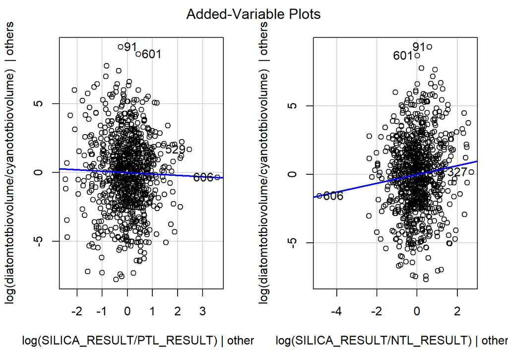

```r
avPlots(fit)
```

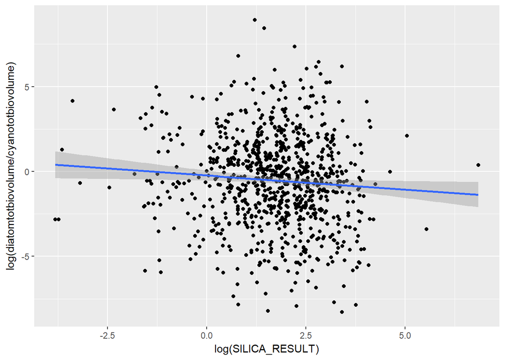

```r
ggplot(data=nla2012_diatoms, mapping = aes(x=log(SILICA_RESULT), y=log(diatomtotbiovolume/cyanototbiovolume)))+
  geom_point()+geom_smooth(method = "lm")
```

```r
fit<-lm(data=nla2012_diatoms, log(diatomtotbiovolume/cyanototbiovolume)~log(SILICA_RESULT))
summary(fit)
```

```
##
## Call:
## lm(formula = log(diatomtotbiovolume/cyanototbiovolume) ~ log(SILICA_RESULT),
##     data = nla2012_diatoms)
##
## Residuals:
##     Min      1Q  Median      3Q     Max
## -7.7237 -1.7870  0.0736  1.7276  9.3576
##
## Coefficients:
##                    Estimate Std. Error t value Pr(>|t|)
## (Intercept)        -0.23645    0.15239  -1.552   0.1211
## log(SILICA_RESULT) -0.16437    0.07131  -2.305   0.0214 *
## ---
## Signif. codes:  0 '***' 0.001 '**' 0.01 '*' 0.05 '.' 0.1 ' ' 1
##
## Residual standard error: 2.718 on 867 degrees of freedom
##   (366 observations deleted due to missingness)
## Multiple R-squared:  0.006092,   Adjusted R-squared:  0.004945
## F-statistic: 5.314 on 1 and 867 DF,  p-value: 0.02139
```

# PART 3 - Effects of Si:P on zooplankton production

## Worth checking if dissolved Si:P and Si:N have any effects on trophic transfer to zooplankton? Si should make for harder to eat diatom prey, P is often limiting for zooplankton, so maybe that combo would make for stronger effects?